# Using Titanic data - Selecting a Model

Abdlmutaleb Boshanna

### 1. Download the data of Titanic.

```r
library(PASWR)
data(titanic3)
str(titanic3)
```

```
## 'data.frame':    1309 obs. of  14 variables:
##  $ pclass   : Factor w/ 3 levels "1st","2nd","3rd": 1 1 1 1 1 1 1 1 1 1 ...
##  $ survived : int  1 1 0 0 0 1 1 0 1 0 ...
##  $ name     : Factor w/ 1307 levels "Abbing, Mr. Anthony",..: 22 24 25 26 27 31 46 47 51 55 ...
##  $ sex      : Factor w/ 2 levels "female","male": 1 2 1 2 1 2 1 2 1 2 ...
##  $ age      : num  29 0.917 2 30 25 ...
##  $ sibsp    : int  0 1 1 1 1 0 1 0 2 0 ...
##  $ parch    : int  0 2 2 2 2 0 0 0 0 0 ...
##  $ ticket   : Factor w/ 929 levels "110152","110413",..: 188 50 50 50 50 125 93 16 77 826 ...
##  $ fare     : num  211 152 152 152 152 ...
##  $ cabin    : Factor w/ 187 levels "","A10","A11",..: 45 81 81 81 81 151 147 17 63 1 ...
##  $ embarked : Factor w/ 4 levels "","Cherbourg",..: 4 4 4 4 4 4 4 4 4 2 ...
##  $ boat     : Factor w/ 28 levels "","1","10","11",..: 13 4 1 1 1 14 3 1 28 1 ...
##  $ body     : int  NA NA NA 135 NA NA NA NA NA 22 ...
##  $ home.dest: Factor w/ 369 levels "","?Havana, Cuba",..: 309 231 231 231 231 237 163 25 23 229 ...
```

### 2. A short description of Titanic data that I will be using in my project, and objective of the data analysis.

We are all familiar with Titanic tragedy. There were approximately 2224 passengers and crew aboard the ship, more than 1500 of died. The data includes 1309 observations, and 14 variables.

I would like to apply Machine learning tools to conduct some analysis on Titanic data to predict what type of people were likely to survive. My label variable (Y) is survifor or died, y is equal 1 if the person survived and equal 0, if the person died. Bascially, I am going to use the data and apply machine learning algrithms which will learn from the data the pattern between who survived and who did not.

### 2. Data management: data cleaning and preparation.

Frist, I’d like to know how many missing values do we have in the data.

```r
sum(is.na(titanic3))
```

```
## [1] 1452
```

Second, I wanted to identify the number of NA’s in each column.

```r
colSums(is.na(titanic3)|titanic3 == 'na')
```

```
##    pclass  survived      name       sex       age     sibsp     parch    ticket
##         0         0         0         0       263         0         0         0
##      fare     cabin  embarked      boat      body home.dest
##         1         0         0         0      1188         0
```

```r
table(is.na(titanic3$age)|titanic3$age == 'na')
```

```
##
## FALSE  TRUE
##  1046   263
```

```r
table(is.na(titanic3$body)|titanic3$body == 'na')
```

```
##
## FALSE  TRUE
##   121  1188
```

Clearly, the data comprises a lot of missing values. Although the data is not a big data, but it is still considered a complicated data because its large missing values. The question is how we handle the missing values?

In this case, one easy way to handle the missing values is to determine the variables that contain many missing values and drop them Or keep only completed values. However, doing that will result in a small number of observations.

```r
data <- titanic3[complete.cases(titanic3), ]
dim(data)
```

```
## [1] 119  14
```

```r
# Now, we have only 119 observations.
```

Let’s use plot to see missing data!

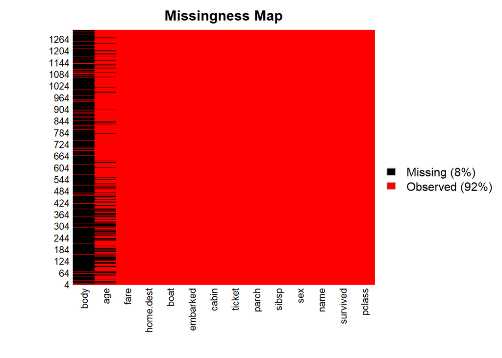

```r
library(Amelia)
missmap(titanic3, col=c("black", "red"))
```

### 3. Feature engineering

Droping the variable with missing values may not be a good approach for this data because if I do that, I will end up with only 119 observations. Therefore, I am going to do feature engineering which is one of the method that helps to imporve model performance prediction. I am going to look at every feature and try to understand it and decide whether I should use it for the model/prediction.

#### 3.1. pclass

The first feature in str(titanic3) is pclass.

Looking at the descriptive of the data, pclass is actually a proxy for socioeconomic status. Basically, class 1, for those who are richer and class 3 for those who are poor. Now, I wanted to see if there are missing values in pclass

```r
table(is.na(titanic3$pclass)|titanic3$pclass == 'na') #there are no missing values!
```

```
##
## FALSE
##  1309
```

```r
table(titanic3$pclass)
```

```
##
## 1st 2nd 3rd
## 323 277 709
```

The distribution across the classes shows that there are a lot more people in third class than class 1 and 2 which makes sense. Interestingly, when I look at the second class, I expect to see more people in the second class than first class. But this is not the case. This patterns can be interesting when we run the models. It is goog to keep that in mind.

Visuallizing pclass and survivied

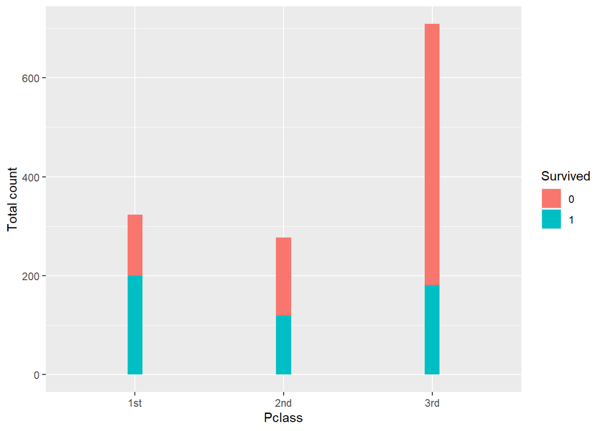

```r
library(ggplot2)
ggplot(titanic3, aes(x = pclass, fill = factor(survived))) + geom_bar(width = 0.1) + xlab("Pclass") + ylab("Total count") + labs(fill = "Survived")
```

From the plot: generally speaking, if you are in the 3th class, you (unfortunately) are more likely to die under the condition all things are equal. However, if you are in the first class, it seems you would have a better chance to survive.

#### 3.2. survived

```r
titanic3$survived <- as.factor(titanic3$survived)
table(is.na(titanic3$survived)|titanic3$survived == 'na')
```

```
##
## FALSE
##  1309
```

Let’s check If I have imbalanced data problem.

```r
table(titanic3$survived)
```

```
##
##   0   1
## 809 500
```

It is 62% and 38%, it is a balanced data because it is around the range 60% 40%.

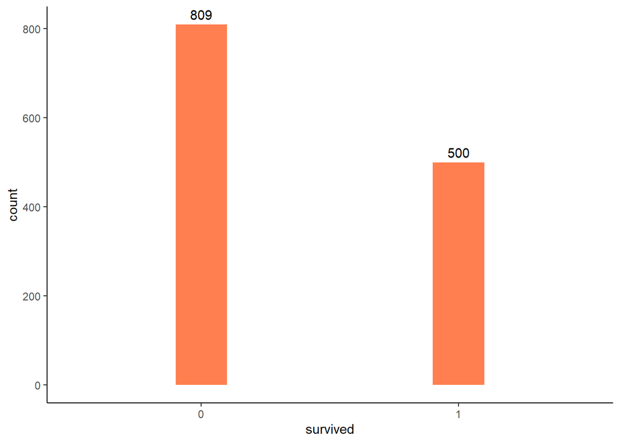

```r
library(ggplot2)
ggplot(titanic3, aes(x = survived)) +
  geom_bar(width=0.2, fill = "coral") +
  geom_text(stat='count', aes(label=stat(count)), vjust=-0.5) +
  theme_classic()
```

#### 3.3. name

Let’s look at name headers. str command shows name as a factor variable. I am going to change it to character. However, you can leave it a factor and you will have a long list of dummy varialbes.

```r
head(as.character(titanic3$name))
```

```
## [1] "Allen, Miss. Elisabeth Walton"   "Allison, Master. Hudson Trevor"
## [3] "Allison, Miss. Helen Loraine"    "Allison, Mr. Hudson Joshua Crei"
## [5] "Allison, Mrs. Hudson J C (Bessi" "Anderson, Mr. Harry"
```

How many unique names do you have in the data

```r
length(unique(as.character(titanic3$name)))
```

```
## [1] 1307
```

Interesting! I expected to see 1309. It seems there are two names are the same. Either a duplicated names Or very common English names. Let’s see

```r
dup.names <- as.character(titanic3[which(duplicated(as.character(titanic3$name))), "name"])
dup.names
```

```
## [1] "Connolly, Miss. Kate" "Kelly, Mr. James"
```

Those names are repeated twice. let’s see why!

```r
titanic3[which(titanic3$name %in% dup.names),]
```

|  | pclass | survived | name | sex | age | sibsp | parch | ticket | fare | cabin | embarked | boat | body | home.dest |
| --- | --- | --- | --- | --- | --- | --- | --- | --- | --- | --- | --- | --- | --- | --- |
| 726 | 3rd | 1 | Connolly, Miss. Kate | female | 22.0 | 0 | 0 | 370373 | 7.7500 |  | Queenstown | 13 | NA | Ireland |
| 727 | 3rd | 0 | Connolly, Miss. Kate | female | 30.0 | 0 | 0 | 330972 | 7.6292 |  | Queenstown |  | NA | Ireland |
| 925 | 3rd | 0 | Kelly, Mr. James | male | 34.5 | 0 | 0 | 330911 | 7.8292 |  | Queenstown |  | 70 |  |
| 926 | 3rd | 0 | Kelly, Mr. James | male | 44.0 | 0 | 0 | 363592 | 8.0500 |  | Southampton |  | NA |  |

Observation number 726 shows Miss. Kate Connolly, who is 22 years old and survived. Observation number 727 shows Miss. Kate Connolly who is 30 years old and did not survive. Therefore, the two women have the same names which is a very common English name. It is the same thing for James Kelly. Therefore, I will keep them because they are not duplicated.

Note, Miss, Mr, etc, they may be helpful/have a predictor power/have interesting pattern/ Or they may be correlated with another variable!

#### 3.3. sex

Let’s see how many female and male do we have in the data.

```r
table(titanic3$sex)
```

```
##
## female   male
##    466    843
```

```r
library(stringr)
miss <- titanic3[which(str_detect(titanic3$name, "Miss")),]
miss[1:4, ]
```

|  | pclass | survived | name | sex | age | sibsp | parch | ticket | fare | cabin | embarked | boat | body | home.dest |
| --- | --- | --- | --- | --- | --- | --- | --- | --- | --- | --- | --- | --- | --- | --- |
| 1 | 1st | 1 | Allen, Miss. Elisabeth Walton | female | 29 | 0 | 0 | 24160 | 211.3375 | B5 | Southampton | 2 | NA | St Louis, MO |
| 3 | 1st | 0 | Allison, Miss. Helen Loraine | female | 2 | 1 | 2 | 113781 | 151.5500 | C22 C26 | Southampton |  | NA | Montreal, PQ / Chesterville, ON |
| 7 | 1st | 1 | Andrews, Miss. Kornelia Theodos | female | 63 | 1 | 0 | 13502 | 77.9583 | D7 | Southampton | 10 | NA | Hudson, NY |
| 14 | 1st | 1 | Barber, Miss. Ellen \\"Nellie\\" | female | 26 | 0 | 0 | 19877 | 78.8500 |  | Southampton | 6 | NA |  |

The four observations show that all four women from first class (pcalss), three out of four survived, thre is a variance of age, and also they left (embarked) from the same place whcih is Southhampton. It is safe to see that this resutls shows that being a female (Miss) and in the first class would reduce the chance of not being died.

let us look at mrs

```r
mrs <- titanic3[which(str_detect(titanic3$name, "Mrs")),]
mrs[1:4, ]
```

|  | pclass | survived | name | sex | age | sibsp | parch | ticket | fare | cabin | embarked | boat | body | home.dest |
| --- | --- | --- | --- | --- | --- | --- | --- | --- | --- | --- | --- | --- | --- | --- |
| 5 | 1st | 0 | Allison, Mrs. Hudson J C (Bessi | female | 25 | 1 | 2 | 113781 | 151.5500 | C22 C26 | Southampton |  | NA | Montreal, PQ / Chesterville, ON |
| 9 | 1st | 1 | Appleton, Mrs. Edward Dale (Cha | female | 53 | 2 | 0 | 11769 | 51.4792 | C101 | Southampton | D | NA | Bayside, Queens, NY |
| 12 | 1st | 1 | Astor, Mrs. John Jacob (Madelei | female | 18 | 1 | 0 | PC 17757 | 227.5250 | C62 C64 | Cherbourg | 4 | NA | New York, NY |
| 18 | 1st | 1 | Baxter, Mrs. James (Helene DeLa | female | 50 | 0 | 1 | PC 17558 | 247.5208 | B58 B60 | Cherbourg | 6 | NA | Montreal, PQ |

Four of them from 1th class(pclass), and 3 out of 4 survived which support the assumption that being in the 1th class would reduce the chance of the perions to died. I can see pattern in the age as well. In general, older females tend to travel with spouse or a kid.

Let’s check out males

```r
males <- titanic3[which(titanic3$sex == "male"),]
males[1:4,]
```

|  | pclass | survived | name | sex | age | sibsp | parch | ticket | fare | cabin | embarked | boat | body | home.dest |
| --- | --- | --- | --- | --- | --- | --- | --- | --- | --- | --- | --- | --- | --- | --- |
| 2 | 1st | 1 | Allison, Master. Hudson Trevor | male | 0.9167 | 1 | 2 | 113781 | 151.55 | C22 C26 | Southampton | 11 | NA | Montreal, PQ / Chesterville, ON |
| 4 | 1st | 0 | Allison, Mr. Hudson Joshua Crei | male | 30.0000 | 1 | 2 | 113781 | 151.55 | C22 C26 | Southampton |  | 135 | Montreal, PQ / Chesterville, ON |
| 6 | 1st | 1 | Anderson, Mr. Harry | male | 48.0000 | 0 | 0 | 19952 | 26.55 | E12 | Southampton | 3 | NA | New York, NY |
| 8 | 1st | 0 | Andrews, Mr. Thomas Jr | male | 39.0000 | 0 | 0 | 112050 | 0.00 | A36 | Southampton |  | NA | Belfast, NI |

The illustration above shows that they are association between survived, class and title. Let’s investigate more the pattern among those features.

```r
titanic3$Tit <- gsub('(.*, )|(\\..*)', '', titanic3$name)
table(titanic3$sex, titanic3$Tit)
```

```
##
##          Capt Col Don Dona  Dr Jonkheer Lady Major Master Miss Mlle Mme  Mr Mrs
##   female    0   0   0    1   1        0    1     0      0  260    2   1   0 197
##   male      1   4   1    0   7        1    0     2     61    0    0   0 757   0
##
##           Ms Rev Sir the Countess
##   female   2   0   0            1
##   male     0   8   1            0
```

```r
# Tit stand for Title but I will creat another variable called "title"
table(titanic3$survived, titanic3$pclass)
```

```
##
##     1st 2nd 3rd
##   0 123 158 528
##   1 200 119 181
```

```r
table(titanic3$pclass, titanic3$Tit)
```

```
##
##       Capt Col Don Dona  Dr Jonkheer Lady Major Master Miss Mlle Mme  Mr Mrs
##   1st    1   4   1    1   6        1    1     2      5   60    2   1 159  77
##   2nd    0   0   0    0   2        0    0     0     11   50    0   0 150  55
##   3rd    0   0   0    0   0        0    0     0     45  150    0   0 448  65
##
##        Ms Rev Sir the Countess
##   1st   0   0   1            1
##   2nd   1   8   0            0
##   3rd   1   0   0            0
```

```r
table(titanic3$survived, titanic3$Tit)
```

```
##
##     Capt Col Don Dona  Dr Jonkheer Lady Major Master Miss Mlle Mme  Mr Mrs  Ms
##   0    1   2   1    0   4        1    0     1     30   84    0   0 634  42   1
##   1    0   2   0    1   4        0    1     1     31  176    2   1 123 155   1
##
##     Rev Sir the Countess
##   0   8   0            0
##   1   0   1            1
```

Therefore, I will create a new variable/feature I call “title”

```r
extracttitle <- function(name){
  name <- as.character(name)

  if(length(grep("Miss.", name)) > 0){
    return("Miss.")
  } else if (length(grep("Master.", name)) > 0){
    return("Master.")
  } else if (length(grep("Mrs.", name)) > 0){
    return("Mrs.")
  } else {
    return("Other")
  }
}

titles <- c()

for(i in 1:nrow(titanic3)){
  titles <- c(titles, extracttitle(titanic3[i, "name"]))
}

titanic3$title <- as.factor(titles)
```

Let’s see the header of title

```r
head(titanic3$title, 4)
```

```
## [1] Miss.   Master. Miss.   Other
## Levels: Master. Miss. Mrs. Other
```

```r
table(titanic3$sex, titanic3$title)
```

```
##
##          Master. Miss. Mrs. Other
##   female       0   260  197     9
##   male        61     0    0   782
```

Let’s do visualization the relationship among survived, pclass, and title.

```r
# I don't know why this code did not run.
library(ggplot2)
##ggplot(titanic3, aes(x = title, fill = survived)) +
  #geom_bar(binwidth = 0.5) +
 # facet_wrap(~pclass) +
  #ggtitle("Pclass") +
 # xlab("title") +
 # ylab("Total count") +
 # Elabs(fill = "Survived")
```

#### 3.4. age

Although age contins 263 missing values, I will keep it because maybe old people or kids could not swim Or they may have been given prourity to leave the ship.

```r
table(is.na(titanic3$age)|titanic3$age == 'na')
```

```
##
## FALSE  TRUE
##  1046   263
```

There are 263 missing values. I can use rpart to handle missing values but I will use the medium instead. Let’s see!

```r
age.median <- median(titanic3$age, na.rm = TRUE)
titanic3[is.na(titanic3$age), "age"] <- age.median
sum(is.na(titanic3$age))
```

```
## [1] 0
```

#### 3.5. sibsp and parch

```r
sum(is.na(titanic3$sibsp)) #there are no missing values!
```

```
## [1] 0
```

```r
sum(is.na(titanic3$parch)) #there are no missing values!
```

```
## [1] 0
```

It may be a good idea to create a new variable which is based on number of siblings/spouse the person has. It can be called family size which includes (sibsp + prach). Also, separating the last name and then create a matrix that includes a person last name and his/her family size. Also, it may be a good idea to infer to people ethnicity based on their last name and add it as a feature to the model and also see the importance of this feature on prediction.

#### 3.6. ticket

```r
sum(is.na(titanic3$ticket))
```

```
## [1] 0
```

#### 3.7. fare

```r
sum(is.na(titanic3$fare)) #there is only one missing value. let's use the median
```

```
## [1] 1
```

```r
fare.median <- median(titanic3$fare, na.rm = TRUE)
titanic3[is.na(titanic3$fare), "fare"] <- fare.median

# then, let's try this
sum(is.na(titanic3$fare))
```

```
## [1] 0
```

#### 3.8. cabin, body, and embarked

```r
sum(is.na(titanic3$cabin)) #there are no missing values!
```

```
## [1] 0
```

```r
sum(is.na(titanic3$body)) #there are 1188 missing values.
```

```
## [1] 1188
```

```r
sum(is.na(titanic3$embarked))
```

```
## [1] 0
```

```r
table(titanic3$pclass, titanic3$embarked)
```

```
##
##           Cherbourg Queenstown Southampton
##   1st   2       141          3         177
##   2nd   0        28          7         242
##   3rd   0       101        113         495
```

```r
table(titanic3$survived, titanic3$embarked)
```

```
##
##         Cherbourg Queenstown Southampton
##   0   0       120         79         610
##   1   2       150         44         304
```

It is interesting to see that Southampton has the highest number of passengers, and it shows 610 died and 304 survived. Queenstown on the other hand, has the lowest number of passenger, and it shows 79 died and 44 survived. Therefore, I will include “embarked” on my model and maybe ML algorithm will find interesting relationship or it helps in prediction.

I will drop some variables such as ticket, body, hhome.distance, and Tit because they contain missing values and also because I think they are not a good predictors too. For example, ID number will not help me to predict whether the persion suvives or died plus body includes 1188 missing values.

```r
titanic3 <- titanic3[, -c(3, 8, 10, 12, 13, 14, 15)]
```

### Here I will use LPM, logistic, KNN, and CART models and then I will select the model that give me higher means AUC and less variation.

### LPM and Logistic

```r
library(caret)
library(MASS)
library(ROCR)

df <- titanic3
df$y <- titanic3$survived
df <- df[, -2] #dropped survived
df <- df[, -7] #dropped embarked because it creates an error when I run Glm, it says factor has new levels.
df$y <- as.factor(df$y)

set.seed(1)

df$y_lm <- as.numeric(df$y)
df$y_lg <- as.factor(df$y)


# Containers
AUC_lm <- c()
AUC_log <- c()


# Loop

for (i in 1:1300) {
ind <- sample(nrow(df), nrow(df)*0.70, replace = FALSE)
tr <- df[ind, ]
tt <- df[-ind,]
# LPM
model <- lm(y_lm ~ ., data = tr[, -c(8,10)])
phat <- predict(model, tt[, -c(8,10)])

# AUC-LM
pred_rocr <- prediction(phat, tt$y_lm)
auc_ROCR <- performance(pred_rocr, measure = "auc")
AUC_lm[i] <- auc_ROCR@y.values[[1]]

# Logistic
model <- glm(y_lg ~ ., data = tr[, -c(8,9)], family = "binomial")
phat <- predict(model, tt[, -c(8,9)], "response")

#AUC
pred_rocr <- prediction(phat, tt$y)
auc_ROCR <- performance(pred_rocr, measure = "auc")
AUC_log[i] <- auc_ROCR@y.values[[1]]
}

mean(AUC_lm)
```

```
## [1] 0.8514344
```

```r
mean(AUC_log)
```

```
## [1] 0.8522095
```

```r
sqrt(var(AUC_lm))
```

```
## [1] 0.01803657
```

```r
sqrt(var(AUC_log))
```

```
## [1] 0.01783002
```

## KNN

```r
# KNN

library(caret)
library(MASS)
library(ROCR)

df <- titanic3
df$y <- titanic3$survived
df <- df[, -2] #dropped survived
df <- df[, -7] #dropped embarked because it creates an error when I run Glm, it says factor has new levels.
#df$embarked <- as.integer(df$embarked)

set.seed(1)

df$y_lm <- as.numeric(df$y)
df$y_lm[df$y_lm==1] <- 0
df$y_lm[df$y_lm==2] <- 1

df$y_lg <- as.factor(df$y)
df$y_knn <- as.factor(df$y)
# Containers

kopt <- c()
MAUC <- c()
AUCk <- c()
# Loop

k <- seq(from = 3, to = 40, by = 1)

for(i in 1:1300){
ind <- sample(nrow(df), nrow(df)*0.70, replace = FALSE)
tr <- df[ind, ]
tt <- df[-ind, ]

for(s in 1:length(k)){
model <- knn3(y_knn ~., data = tr[, -c(8, 9, 10)], k = k[s])
phat <- predict(model, tt[, -c(8,9,10)], type = "prob")
#AUC
pred_rocr <- prediction(phat[,2], tt$y)
auc_ROCR <- performance(pred_rocr, measure = "auc")
AUCk[s] <- auc_ROCR@y.values[[1]]
}
kopt[i] <- k[which.max(AUCk)]
MAUC[i] <- AUCk[which.max(AUCk)]
}

mean(MAUC)
```

```
## [1] 0.7467148
```

```r
sqrt(var(MAUC))
```

```
## [1] 0.01991266
```

## CART: decision tree

```r
remove(list = ls())

extracttitle <- function(name){
  name <- as.character(name)

  if(length(grep("Miss.", name)) > 0){
    return("Miss.")
  } else if (length(grep("Master.", name)) > 0){
    return("Master.")
  } else if (length(grep("Mrs.", name)) > 0){
    return("Mrs.")
  } else {
    return("Other")
  }
}

titles <- c()

for(i in 1:nrow(titanic3)){
  titles <- c(titles, extracttitle(titanic3[i, "name"]))
}

titanic3$title <- as.factor(titles)
```

```r
library(PASWR)
library(ROCR)
library(rpart)

# Data
#remove(list = ls())
#data(titanic3)
df <- titanic3

# Containers
MAUC <- c()
AUC <- c()

# Complexity Parameter (cp)
cpgrid <- seq(from = 0.01, to = 0.05, by = 0.001)

# Loop
set.seed(1)
for(i in 1:100){
  ind <- sample(nrow(df), nrow(df), replace = TRUE)
  ind <- unique(ind)
  tr <- df[ind, ]
  tt <- df[-ind, ]

  for(s in 1:length(cpgrid)){
    model <- rpart(survived ~ pclass + sex + age + sibsp + parch + fare + title,
                  data=tr, method="class",
                  control = rpart.control(minsplit = 2, minbucket = 1,
                  cp = 0))
    pmodel <- prune(model, cp = cpgrid[s])
    phat <- predict(pmodel, tt, type = "prob")

    #AUC
    pred_rocr <- prediction(phat[,2], tt$survived)
    auc_ROCR <- performance(pred_rocr, measure = "auc")
    AUC[s] <- auc_ROCR@y.values[[1]]
  }
MAUC[i] <- max(AUC)
}
```

```r
mean(MAUC)
```

```
## [1] 0.8175358
```

```r
sqrt(var(MAUC))
```

```
## [1] 0.01971923
```

## Variable importance

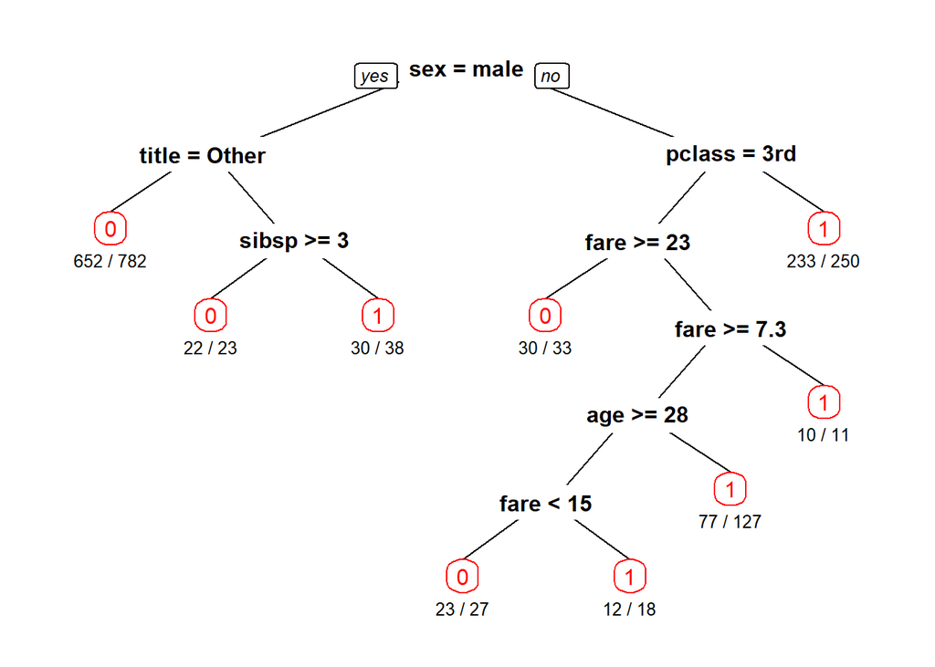

```r
library(rpart)
library(rpart.plot)
# Classification tree
titan <- rpart(survived~ pclass + sex + age + sibsp + parch + embarked + fare + title, data=titanic3, method="class")
prp(titan, extra=2, faclen=8, col="red", under = TRUE)
```

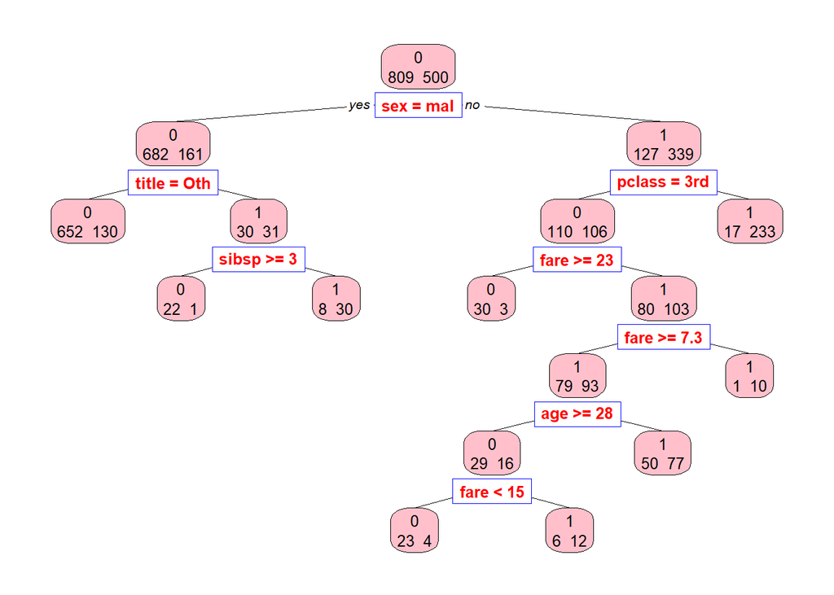

```r
prp(titan, type = 2, extra = 1, split.col = "red",
    split.border.col = "blue", box.col = "pink")
```

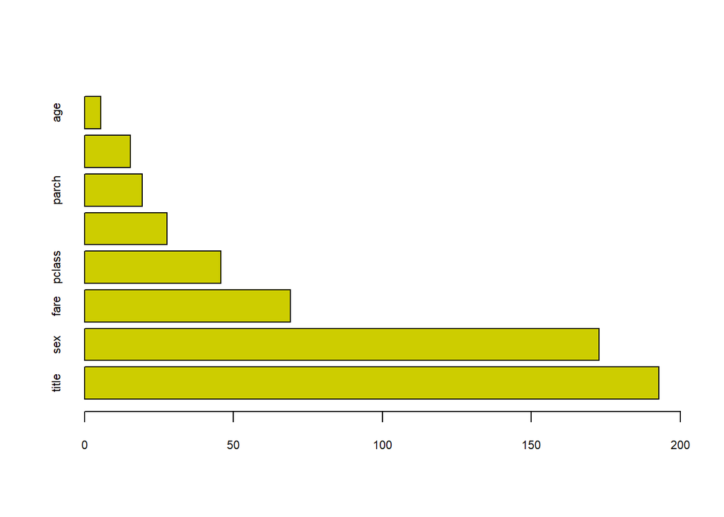

```r
barplot(titan$variable.importance, horiz=TRUE,
        col="yellow3", cex.axis = 0.7, cex.names = 0.7, xlim = c(0,200))
```

```r
library(PASWR)
library(ROCR)
library(rpart)

# Data
#remove(list = ls())
#data(titanic3)
df <- titanic3

# Containers
MAUC <- c()
AUC <- c()
cpopt <- c()

# Complexity Parameter (cp)
cpgrid <- seq(from = 0.01, to = 0.05, by = 0.001)

# Loop
for(s in 1:length(cpgrid)){
  for(i in 1:100){
    ind <- sample(nrow(df), nrow(df), replace = TRUE)
    ind <- unique(ind)
    tr <- df[ind, ]
    tt <- df[-ind, ]

    model <- rpart(survived~ pclass + sex + age + sibsp + parch + fare + title,
                  data=tr, method="class",
                  control = rpart.control(minsplit = 2, minbucket = 1,
                  cp = 0))
    pmodel <- prune(model, cp = cpgrid[s])
    phat <- predict(pmodel, tt, type = "prob")

    #AUC
    pred_rocr <- prediction(phat[,2], tt$survived)
    auc_ROCR <- performance(pred_rocr, measure = "auc")
    AUC[i] <- auc_ROCR@y.values[[1]]
  }
MAUC[s] <- mean(AUC)
}
max(MAUC)
```

```
## [1] 0.8156704
```

```r
cpopt <- cpgrid[which.max(MAUC)]
cpopt
```

```
## [1] 0.011
```

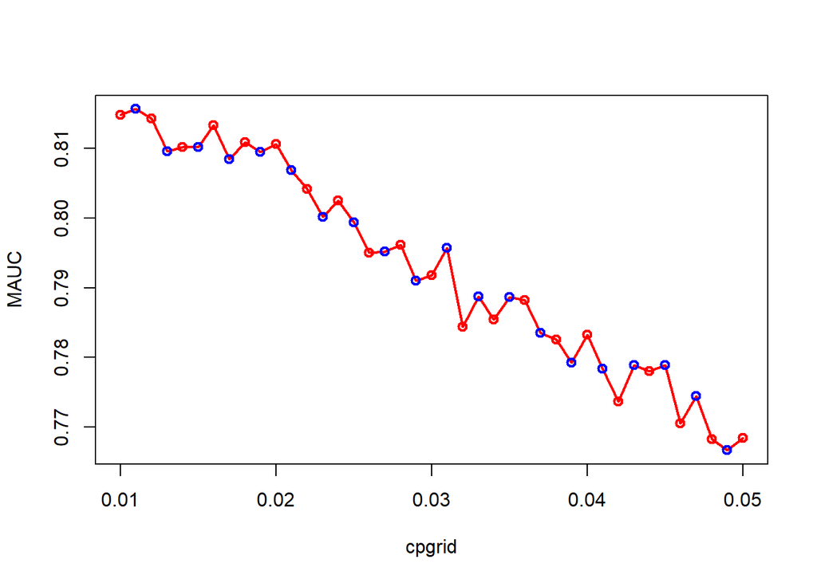

```r
plot(cpgrid, MAUC, col = c("red", "blue"), type = "o", lwd = 2)
```

### 4. Final Model: If your script in Step 3 selects kNN or CART, write another script to report the tuned kNN or CART. At this stage, you have to use the final model on the test set and report your performance criteria.

Hypothetically speaking, If I were to choose the second model CART and I would want to write another script to report the tuned CART, here is what I would do:

```r
df <- titanic3

tree = rpart(survived ~ pclass + sex + age + sibsp + parch + fare + title, data = df, method = "class")

titan <- rpart(survived ~ pclass + sex + age + sibsp + parch + fare + title, data=df, method="class")
```

```r
printcp(titan)
```

```
##
## Classification tree:
## rpart(formula = survived ~ pclass + sex + age + sibsp + parch +
##     fare + title, data = df, method = "class")
##
## Variables actually used in tree construction:
## [1] age    fare   pclass sex    sibsp  title
##
## Root node error: 500/1309 = 0.38197
##
## n= 1309
##
##      CP nsplit rel error xerror     xstd
## 1 0.424      0     1.000  1.000 0.035158
## 2 0.027      1     0.576  0.594 0.030306
## 3 0.022      3     0.522  0.530 0.029076
## 4 0.013      5     0.478  0.488 0.028179
## 5 0.012      7     0.452  0.488 0.028179
## 6 0.010      8     0.440  0.498 0.028400
```

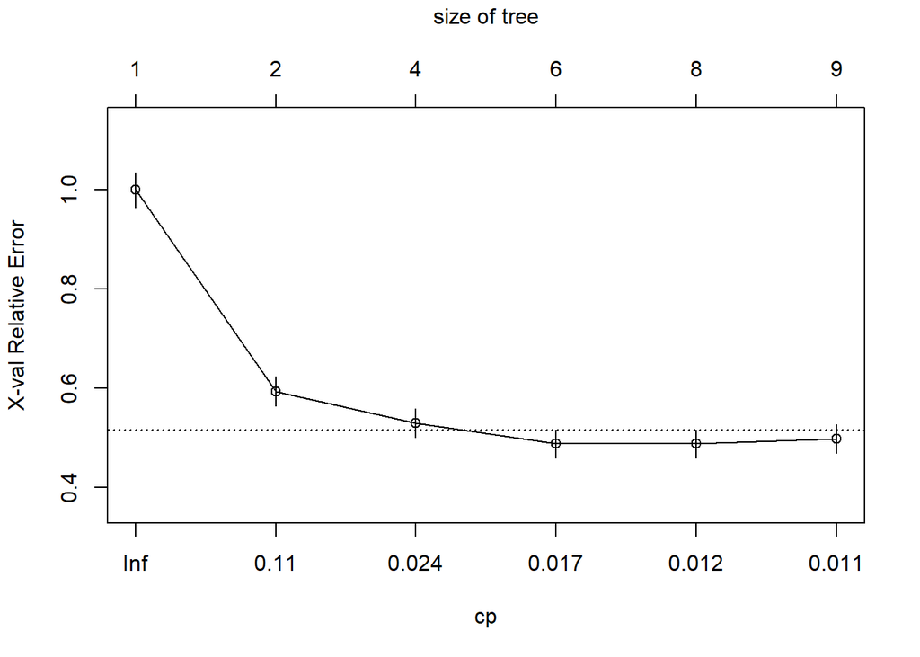

```r
plotcp(titan)
```

```r
set.seed(1)
ind <- sample(nrow(titanic3), nrow(titanic3)*0.7)
train <- titanic3[ind, ]
test <- titanic3[-ind, ]
# Tree with TPR
titan2 <- rpart(survived ~ pclass + sex + age + sibsp + parch + fare + title, data=train, method="class")
pred <- predict(titan2, test, type = "class")
tpr <- mean(pred == test$survived)
tpr
```

```
## [1] 0.7709924
```

```r
# Tree with AUC
phat <- predict(titan2, test, type = "prob")
head(phat)
```

```
##             0         1
## 1  0.06521739 0.9347826
## 2  0.16666667 0.8333333
## 4  0.83733826 0.1626617
## 9  0.06521739 0.9347826
## 10 0.83733826 0.1626617
## 12 0.06521739 0.9347826
```

```r
pred_rocr <- prediction(phat[,2], test$survived)
auc_ROCR <- performance(pred_rocr, measure = "auc")
auc_ROCR@y.values[[1]]
```

```
## [1] 0.8215068
```

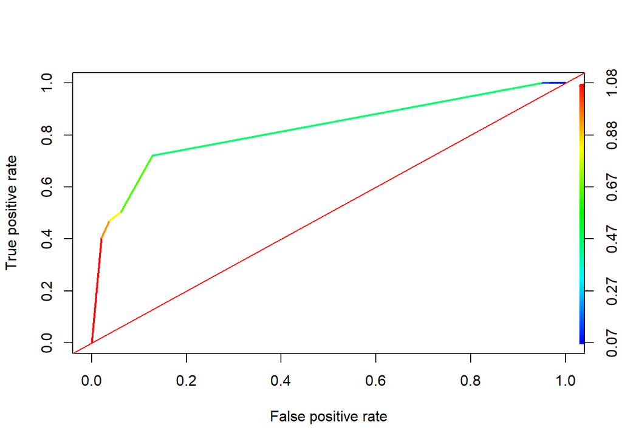

```r
#ROC
perf <- performance(pred_rocr,"tpr","fpr")
plot(perf, colorize=TRUE, lwd = 2)
abline(a = 0, b = 1, col = "red")
```